# Assignment 5 - Statistics II, Hertie School

### Task 1 - On the search for plausible instruments [4 points in total]

Come up with a plausible instrument in the following scenarios and justify your choice in 1-3 sentences.

1. Scenario 1 [2 pts]  
   Units: US counties at US House election  
   Treatment: voter turnout  
   Outcome: share of Democrat party

The researcher can encourage one group to vote by sending reminder text messages, but not to the other. Subjects should be randomly assigned to the encouragement group to ensure that the share of democratic party is not correlated with the instrumental variables. Since the instrument variable will only affect the outcome through treatment, is observable (0 or 1), and is independent from the outcome, it is a plausible instrumental variable.

2. Scenario 2 [2 pts]  
   Units: Voters  
   Treatment: exposure to Fox News  
   Outcome: vote for Republican party

The position of Fox channel in the cable network affects exposure to Fox News. In a region where Fox News has the default position, viewers will access Fox News more easily. While it is not correlated with the share of democratic party, it can affect the vote for republican party through the mediator, exposure to fox news channel.

### Task 2 - Bert and Ernie’s impact on letter recognition [14 points in total]

Suppose we want to estimate the effect of watching an educational television program - Sesame Street - on letter recognition. We might consider implementing a randomized experiment where the participants are preschool children, the treatment of interest is watching Sesame Street, the control condition is not watching, and the outcome is the score on a test of letter recognition. It is not possible here for the experimenter to force children to watch a TV show or to refrain from watching (the experiment took place while Sesame Street was on the air).

```r
dat <- read.dta("sesame.dta")
```

Using the dataset `sesame.dta` where letter recognition is the outcome of interest (`postlet`), regularly watching Sesame Street is the treatment (`regular`) and the encouragement to watch is the instrument (`encour`), do the following:

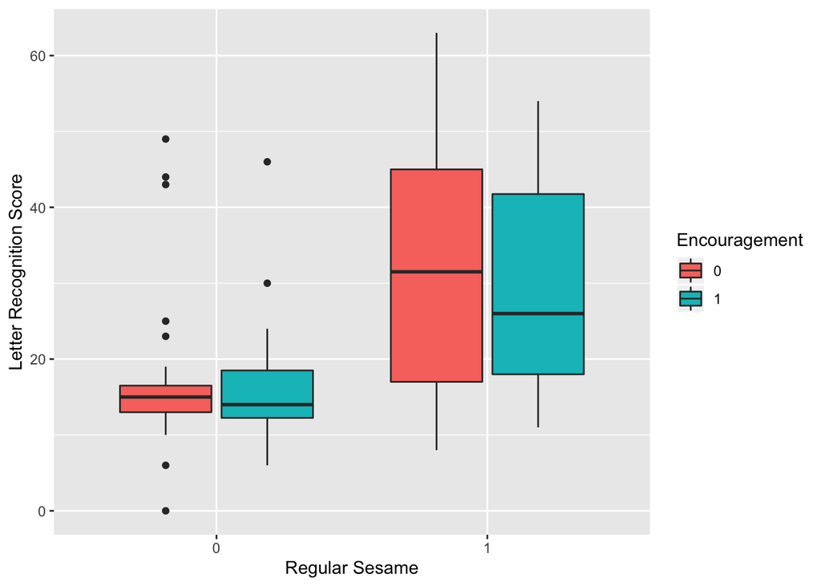

```r
ggplot(dat, aes(x=factor(regular),
                y=postlet,
                fill=factor(encour))) +
  geom_boxplot() + xlab("Regular Sesame") + ylab("Letter Recognition Score") + labs(fill="Encouragement")
```

3. What do we know about non-compliance in the data? Give a table or visual representation plus a short description. Also, report a statistic showing whether the encouragement can or cannot be considered a strong instrument. [2 pts]

```r
st_options(footnote=NA)
print(ctable(dat$regular, dat$encour, prop="n"), method="render")
```

Cross-Tabulation

regular * encour

**Data Frame**: dat

| **regular** | encour 0 | encour 1 | Total |
| --- | --- | --- | --- |
| **0** | 40 | 14 | 54 |
| **1** | 48 | 138 | 186 |
| **Total** | 88 | 152 | 240 |

Assuming that there are no defiers, the cross-table tells us that there are 14 never-takers who were encouraged (E=1) but did not watch regularly (R=0), and 48 always-takers who were not encouraged(E=0) but watched the show regularly (R=1). In total, there are 62 non-compliers in this experiment.

```r
summary(lm(regular~encour, dat))
```

```
##
## Call:
## lm(formula = regular ~ encour, data = dat)
##
## Residuals:
##      Min       1Q   Median       3Q      Max
## -0.90789  0.09211  0.09211  0.09211  0.45455
##
## Coefficients:
##             Estimate Std. Error t value Pr(>|t|)
## (Intercept)  0.54545    0.04060  13.434  < 2e-16 ***
## encour       0.36244    0.05102   7.104  1.4e-11 ***
## ---
## Signif. codes:  0 '***' 0.001 '**' 0.01 '*' 0.05 '.' 0.1 ' ' 1
##
## Residual standard error: 0.3809 on 238 degrees of freedom
## Multiple R-squared:  0.1749, Adjusted R-squared:  0.1715
## F-statistic: 50.46 on 1 and 238 DF,  p-value: 1.397e-11
```

Linear regression of ‘regular’ on ‘encour’ shows us that the relevance of our instrumental variable is statistically significant. The F statistic (50.46), is much greater than 10, which means that the encourgement is a strong instrument. Substantively speaking, 54% of children who were not encouraged watched Sesame, while 90% of children who were encouraged watched Sesame.